# STest 1

Name_ID

2025-03-04

## Bài kiểm tra 1

Bạn là một nhà phân tích dữ liệu làm việc cho một công ty bán lẻ. Công ty muốn khảo sát mức độ hài lòng của khách hàng đối với dịch vụ của mình. Dữ liệu khách hàng được chia thành 5 nhóm dựa trên khu vực (A, B, C, D, E). Mỗi khu vực có số lượng khách hàng khác nhau. Bạn cần thực hiện các bước sau:

1. **Tạo dữ liệu giả lập**:
   - Tạo một bộ dữ liệu gồm 1000 khách hàng với các thông tin sau:
     - Biến id: Từ 1 đến 1000.
     - Biến region: Khu vực địa lý (A, B, C, D, E), với số lượng khách hàng lần lượt là 200, 300, 150, 250, 100.
     - Biến satisfaction_score: Điểm hài lòng của khách hàng (từ 1 đến 10), được tạo ngẫu nhiên từ phân phối chuẩn với mean = 7 và sd =2.

```r
# Tạo dữ liệu giả lập trong R
set.seed(123)  # Đặt seed để kết quả có thể tái lập

# Định nghĩa số lượng khách hàng cho từng khu vực
regions <- c(rep('A', 200), rep('B', 300), rep('C', 150), rep('D', 250), rep('E', 100))

# Tạo ID cho khách hàng
customer_ids <- 1:1000

# Tạo điểm hài lòng từ phân phối chuẩn với mean=7, sd=2
satisfaction_scores <- rnorm(1000, mean=7, sd=2)
satisfaction_scores <- pmax(pmin(satisfaction_scores, 10), 1)  # Giới hạn điểm trong khoảng 1-10

# Tạo DataFrame
data <- data.frame(
  id = customer_ids,
  region = regions,
  satisfaction_score = satisfaction_scores
)

# Xem trước dữ liệu
head(data)
```

```
##   id region satisfaction_score
## 1  1      A           5.879049
## 2  2      A           6.539645
## 3  3      A          10.000000
## 4  4      A           7.141017
## 5  5      A           7.258575
## 6  6      A          10.000000
```

2. **Lấy mẫu**:
   - Phân tầng dữ liệu dựa trên biến region.
   - Trong mỗi tầng, áp dụng lấy mẫu hệ thống để chọn 10% số lượng khách hàng.
   - Kết hợp các mẫu từ tất cả các tầng thành một bộ dữ liệu cuối cùng.

```r
# Lấy mẫu phân tầng theo region
library(dplyr)
sampled_data <- data %>%
  group_by(region) %>%
  slice_sample(prop = 0.1) %>%  # Chọn 10% từ mỗi khu vực
  ungroup()

# Xem trước dữ liệu mẫu
head(sampled_data)
```

```
## # A tibble: 6 × 3
##      id region satisfaction_score
##   <int> <chr>               <dbl>
## 1    49 A                    8.56
## 2   178 A                    7.62
## 3    42 A                    6.58
## 4   139 A                   10
## 5    65 A                    4.86
## 6    98 A                   10
```

3. **Đánh giá sai số**:
   - Tính **giá trị trung bình (mean)** và **độ lệch chuẩn (standard deviation)** của biến satisfaction_score trong toàn bộ dữ liệu gốc.
   - Tính **giá trị trung bình (mean)** và **độ lệch chuẩn (standard deviation)** của biến satisfaction_score trong mẫu đã lấy.
   - Tính **sai số tuyệt đối (absolute error)** và **sai số tương đối (relative error)** giữa giá trị trung bình của mẫu và giá trị trung bình của tổng thể.
   - Đánh giá xem mẫu có đại diện tốt cho tổng thể hay không dựa trên sai số.

```r
# Đánh giá sai số
mean_total <- mean(data$satisfaction_score)
sd_total <- sd(data$satisfaction_score)

mean_sample <- mean(sampled_data$satisfaction_score)
sd_sample <- sd(sampled_data$satisfaction_score)

absolute_error <- abs(mean_sample - mean_total)
relative_error <- absolute_error / mean_total * 100

# Kết quả
cat("Mean (Total):", mean_total, "\n")
```

```
## Mean (Total): 6.965458
```

```r
cat("SD (Total):", sd_total, "\n")
```

```
## SD (Total): 1.852724
```

```r
cat("Mean (Sample):", mean_sample, "\n")
```

```
## Mean (Sample): 7.010579
```

```r
cat("SD (Sample):", sd_sample, "\n")
```

```
## SD (Sample): 1.755491
```

```r
cat("Absolute Error:", absolute_error, "\n")
```

```
## Absolute Error: 0.04512061
```

```r
cat("Relative Error (%):", relative_error, "\n")
```

```
## Relative Error (%): 0.6477766
```

4. **Phân tích kết quả**:
   - So sánh phân phối của biến satisfaction_score giữa tổng thể và mẫu bằng biểu đồ histogram.
   - Đưa ra kết luận về chất lượng mẫu và đề xuất cải tiến (nếu cần).

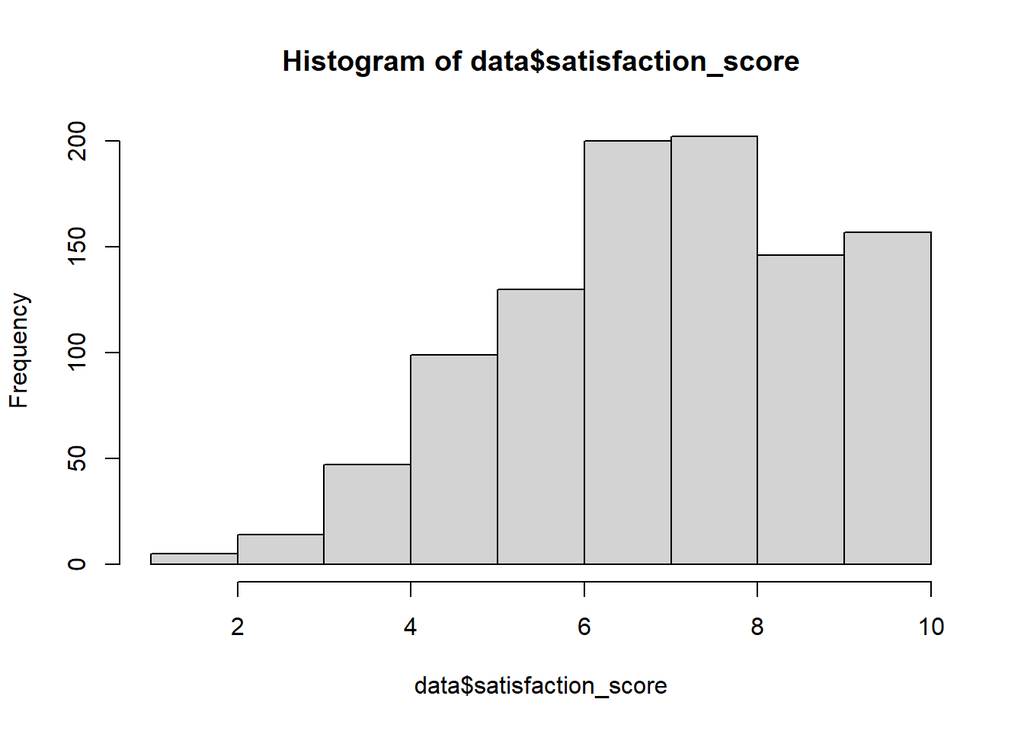

```r
#So sánh phân phối của biến satisfaction_score giữa tổng thể và mẫu bằng biểu đồ histogram.
hist(data$satisfaction_score)
```

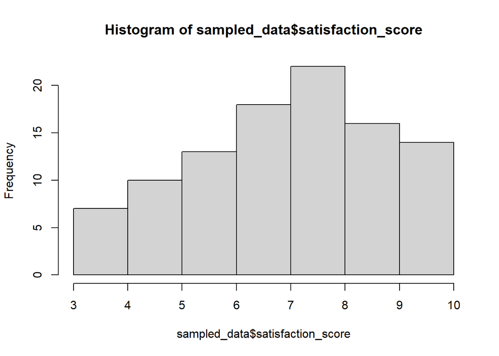

```r
hist(sampled_data$satisfaction_score)
```

```r
#Đưa ra kết luận về chất lượng mẫu và đề xuất cải tiến (nếu cần).
#Mẫu có phân phối gần chuẩn
```